# PrelimPlots

Rachel Lee

4/3/2020

```r
library(tidyverse)
cmpst_all = read_csv(file = "/Users/rachellee/Google Drive/Practicum/Data/cmpst_all.csv") %>%
 janitor::clean_names() %>%
 mutate( visit = forcats::fct_relevel(visit, c("Screen", "Baseline", "Week3", "Week6", "Week9", "Week14", "Week24")))
#names(cmpst_all)


str(cmpst_all)
```

```
## Classes 'spec_tbl_df', 'tbl_df', 'tbl' and 'data.frame': 1094 obs. of  64 variables:
##  $ x1                      : num  1 2 3 4 5 6 7 8 9 10 ...
##  $ patient_id              : num  4000 4000 4000 4000 4000 ...
##  $ interview_id            : chr  "Baseline" "Screen" "Week14" "Week24" ...
##  $ sub_id                  : num  4000 4000 4000 4000 4000 ...
##  $ site                    : chr  "UCSF" "UCSF" "UCSF" "UCSF" ...
##  $ tx_text                 : chr  "CM" "CM" "CM" "CM" ...
##  $ visit                   : Factor w/ 8 levels "Screen","Baseline",..: 2 1 6 7 3 4 5 2 1 6 ...
##  $ gender                  : chr  "Female" "Female" "Female" "Female" ...
##  $ age                     : num  68 68 68 68 68 68 68 81 81 81 ...
##  $ education               : num  12 12 12 12 12 12 12 12 12 12 ...
##  $ race                    : chr  "Black/African American" "Black/African American" "Black/African American" "Black/African American" ...
##  $ ham24tot                : num  27 27 8 5 15 13 11 23 24 14 ...
##  $ whodastot               : num  34 NA 30 34 30 28 30 40 NA 36 ...
##  $ whodastotpro            : num  34 NA 30 34 30 28 30 40 NA 36 ...
```

[output cut: 50 more lines]

Stroop: The Stroop Color and Word Test (SCWT) is a neuropsychological test extensively used to assess the ability to inhibit cognitive interference that occurs when the processing of a specific stimulus feature impedes the simultaneous processing of a second stimulus attribute, well-known as the Stroop Effect.

```r
#baseline data

cmpst_all %>%
  select(patient_id, visit, stroop_color, stroop_word, stroop_color_word) %>%
  filter(visit == "Baseline") %>%
  drop_na() %>%
  summarize(
    n(),
    mean_color = mean(stroop_color),
    sd_color = sd(stroop_color),
    mean_word = mean(stroop_word),
    sd_word = sd(stroop_word),
    mean_colorword = mean(stroop_color_word),
    sd_colorword = sd(stroop_color_word)
  ) %>%
 knitr::kable()
```

| n() | mean_color | sd_color | mean_word | sd_word | mean_colorword | sd_colorword |
| --- | --- | --- | --- | --- | --- | --- |
| 152 | 52.47368 | 17.14177 | 71.875 | 18.02622 | 22.36184 | 10.32232 |

HVLT: Hopkins Verbal Learning test, assess acquisition and delayed recall, detecting the earliest signs of dementia

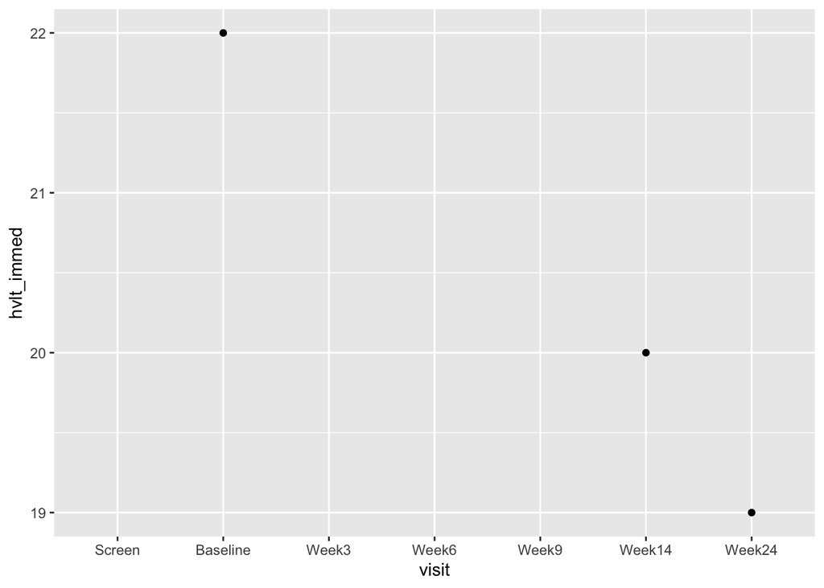

```r
#longitudinal plots
cmpst_hvlt <- select(cmpst_all, patient_id, gender, visit, hvlt_immed, hvlt_discrim)

cmpst_hvlt %>%
  filter(patient_id == 4000) %>%
  ggplot(aes(x=visit, y = hvlt_immed)) +
  geom_point()
```

```r
#calculate the difference
cmpst_hvlt_immed <- cmpst_hvlt %>%
  select(patient_id, gender, visit, hvlt_immed) %>%
  drop_na() %>%
 pivot_wider(
  names_from = "visit",
  values_from = "hvlt_immed",
  ) %>%
  select(-Week24) %>%
  mutate(
    change = Week14 - Baseline
  )

cmpst_hvlt_immed
```

```
## # A tibble: 162 x 5
##    patient_id gender Baseline Week14 change
##         <dbl> <chr>     <dbl>  <dbl>  <dbl>
##  1       4000 Female       22     20     -2
##  2       4001 Female       17     NA     NA
##  3       4006 Male         NA     13     NA
##  4       4007 Male         15     14     -1
##  5       4010 Female       16     13     -3
##  6       4011 Female        9     NA     NA
##  7       4012 Female       13     12     -1
##  8       4013 Female       17     16     -1
##  9       4014 Female       17     15     -2
## 10       4019 Female       11     15      4
## # … with 152 more rows
```

Comment: Lots of observations are missing Week14.

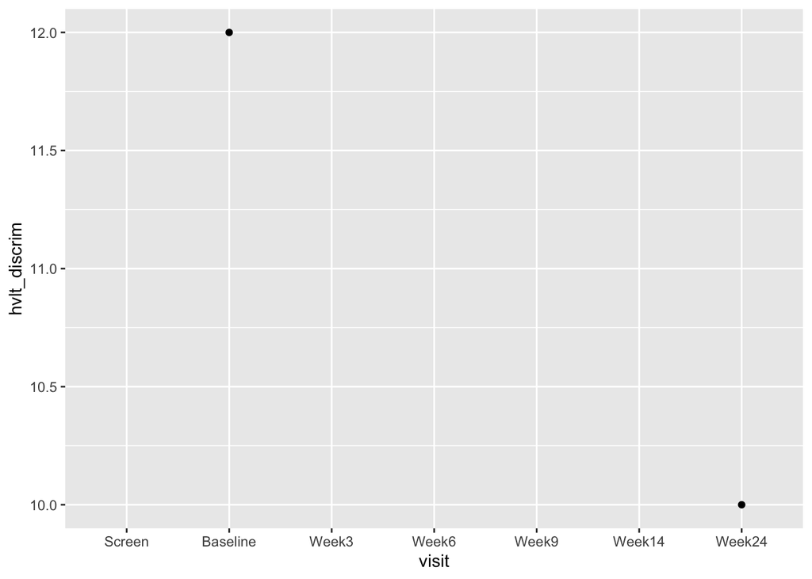

```r
#longitudinal plots
cmpst_hvlt %>%
  filter(patient_id == 4001) %>%
  ggplot(aes(x=visit, y = hvlt_discrim)) +
  geom_point()
```

```r
#calculate the difference
cmpst_hvlt_discrim <- cmpst_all %>%
  select(patient_id, gender, visit, hvlt_discrim) %>%
  drop_na() %>%
 pivot_wider(
  names_from = "visit",
  values_from = "hvlt_discrim",
  ) %>%
  select(-Week24) %>%
  mutate(
    change = Week14 - Baseline
  )

cmpst_hvlt_discrim
```

```
## # A tibble: 158 x 5
##    patient_id gender Baseline Week14 change
##         <dbl> <chr>     <dbl>  <dbl>  <dbl>
##  1       4000 Female        9     12      3
##  2       4001 Female       12     NA     NA
##  3       4006 Male         NA      6     NA
##  4       4007 Male          7      9      2
##  5       4010 Female        8      7     -1
##  6       4011 Female        2     NA     NA
##  7       4012 Female        7      7      0
##  8       4013 Female        7     11      4
##  9       4014 Female        4      5      1
## 10       4019 Female        5     10      5
## # … with 148 more rows
```

Comment: Lots of observations are missing Week14.

Treatment Rational Scale

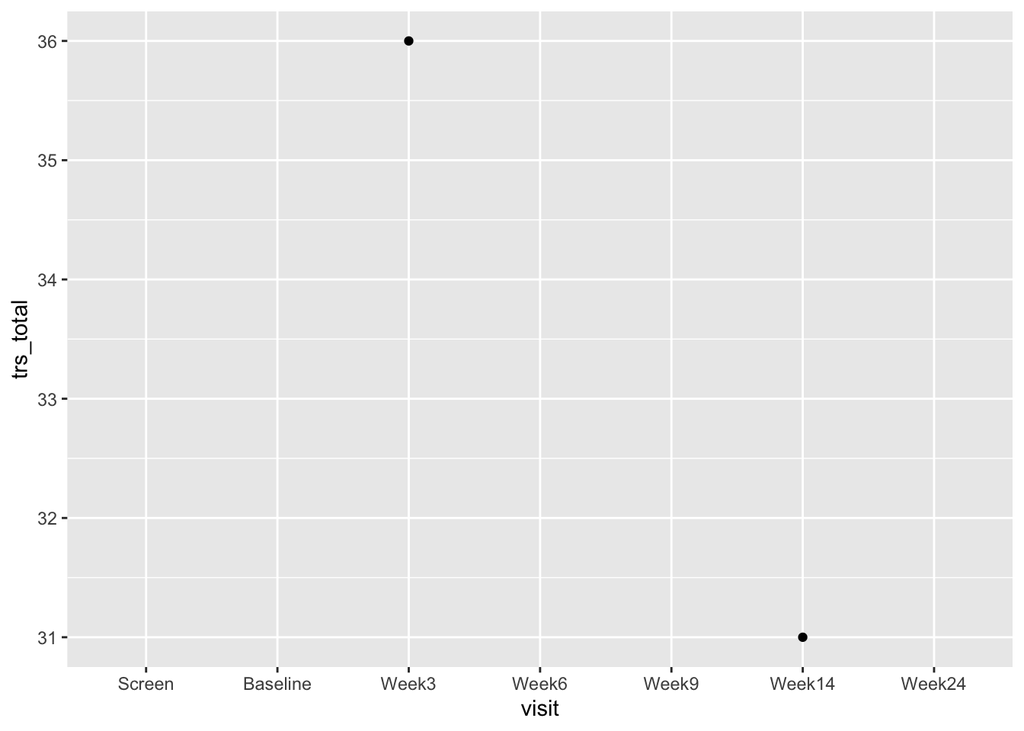

```r
cmpst_trs <- cmpst_all %>%
  select(patient_id, gender, visit, trs_total)

#longitudinal plot

cmpst_trs %>%
  filter(patient_id == 4001) %>%
  ggplot(aes(x=visit, y=trs_total)) +
  geom_point()
```

```r
#calculate the difference

cmpst_trs <- cmpst_all %>%
  select(patient_id, gender, visit, trs_total) %>%
  drop_na() %>%
 pivot_wider(
  names_from = "visit",
  values_from = "trs_total",
  ) %>%
  mutate(
    change = Week14 - Week3
  )

cmpst_trs
```

```
## # A tibble: 159 x 5
##    patient_id gender Week3 Week14 change
##         <dbl> <chr>  <dbl>  <dbl>  <dbl>
##  1       4000 Female    31     NA     NA
##  2       4001 Female    36     31     -5
##  3       4007 Male      23     20     -3
##  4       4010 Female    39     27    -12
##  5       4011 Female    21     NA     NA
##  6       4012 Female    32     34      2
##  7       4013 Female    36     40      4
##  8       4014 Female    40     34     -6
##  9       4019 Female    34     33     -1
## 10       4020 Female    31     NA     NA
## # … with 149 more rows
```

PANAS: Positive & Negative Affect Scores can range from 10-50 for both the Positive and Negative Affect with the lower scores representing lower levels of Positive/Negative Affect and higher scores representing higher levels of Positive/Negative Affect. Participants utilizing PANAS use a 5-point scale in which they determine if a concept applies.

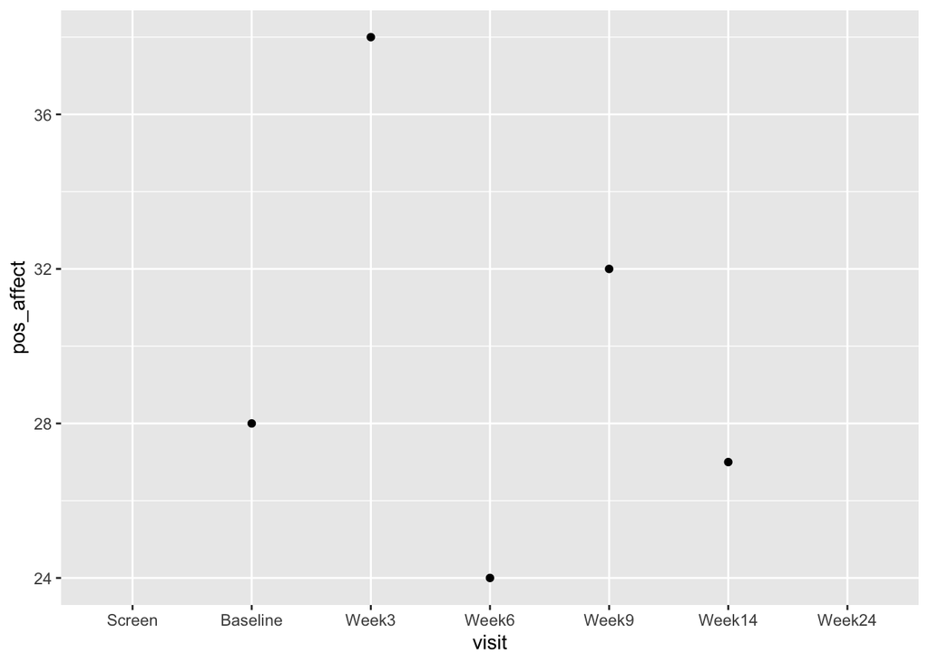

```r
cmpst_panas <- cmpst_all %>%
  select(patient_id, gender, visit, pos_affect, neg_affect)

cmpst_panas_pos <- cmpst_panas %>%
  select(patient_id, gender, visit, pos_affect)

cmpst_panas_neg <- cmpst_panas %>%
  select(patient_id, gender, visit, neg_affect)

#Logitudinal plot

cmpst_panas_pos %>%
  filter(patient_id == 4001) %>%
  ggplot(aes(x=visit, y=pos_affect)) +
  geom_point()
```

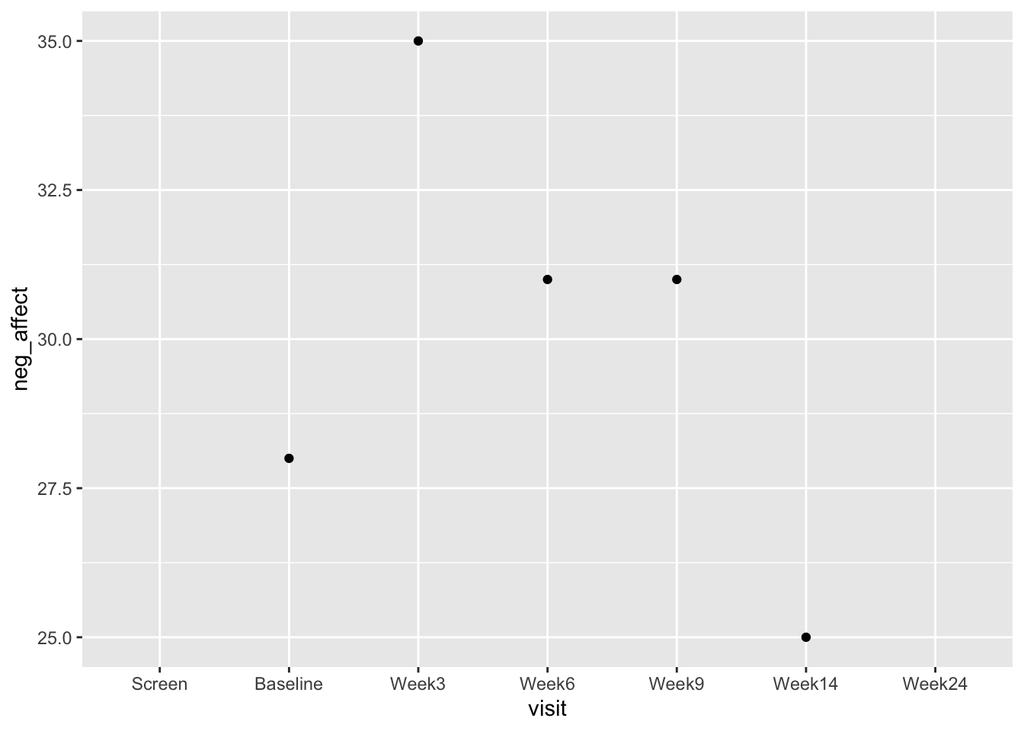

```r
cmpst_panas_neg %>%
  filter(patient_id == 4001) %>%
  ggplot(aes(x=visit, y=neg_affect)) +
  geom_point()
```

```r
##calculate the difference of posaffect

cmpst_panas_pos <- cmpst_panas_pos %>%
  drop_na() %>%
 pivot_wider(
  names_from = "visit",
  values_from = "pos_affect",
  ) %>%
  mutate(
    change = Week14 - Baseline
  )
cmpst_panas_pos
```

```
## # A tibble: 170 x 8
##    patient_id gender Baseline Week3 Week6 Week9 Week14 change
##         <dbl> <chr>     <dbl> <dbl> <dbl> <dbl>  <dbl>  <dbl>
##  1       4000 Female       34    38    39    31     NA     NA
##  2       4001 Female       28    38    24    32     27     -1
##  3       4007 Male         32    34    25    27     35      3
##  4       4010 Female       24    24    24    24     26      2
##  5       4011 Female       28    38    29    NA     NA     NA
##  6       4012 Female       28    35    30    33     36      8
##  7       4013 Female       38    38    42    28     46      8
##  8       4014 Female       31    37    34    40     40      9
##  9       4019 Female       17    18    20    17     19      2
## 10       4020 Female       19    27    24    20     NA     NA
## # … with 160 more rows
```

```r
##calculate the difference of negaffect

cmpst_panas_neg <- cmpst_panas_neg %>%
  drop_na() %>%
 pivot_wider(
  names_from = "visit",
  values_from = "neg_affect",
  ) %>%
  mutate(
    change = Week14 - Baseline
  )
cmpst_panas_neg
```

```
## # A tibble: 171 x 8
##    patient_id gender Baseline Week3 Week6 Week9 Week14 change
##         <dbl> <chr>     <dbl> <dbl> <dbl> <dbl>  <dbl>  <dbl>
##  1       4000 Female       16    19    10    10     NA     NA
##  2       4001 Female       28    35    31    31     25     -3
##  3       4006 Male         14    NA    NA    NA     NA     NA
##  4       4007 Male         26    31    26    26     35      9
##  5       4010 Female       22    18    14    17     20     -2
##  6       4011 Female       33    20    20    NA     NA     NA
##  7       4012 Female       13    28    29    21     16      3
##  8       4013 Female       15    16    19    13     13     -2
##  9       4014 Female       32    20    19    21     22    -10
## 10       4019 Female       42    46    41    41     41     -1
## # … with 161 more rows
```

```r
cmpst_madrs <- cmpst_all %>%
  select(patient_id, gender, visit, madrs_total)

cmpst_madrs
```

```
## # A tibble: 1,094 x 4
##    patient_id gender visit    madrs_total
##         <dbl> <chr>  <fct>          <dbl>
##  1       4000 Female Baseline          NA
##  2       4000 Female Screen            NA
##  3       4000 Female Week14            NA
##  4       4000 Female Week24             2
##  5       4000 Female Week3             NA
##  6       4000 Female Week6             NA
##  7       4000 Female Week9             NA
##  8       4001 Female Baseline          NA
##  9       4001 Female Screen            NA
## 10       4001 Female Week14            NA
## # … with 1,084 more rows
```

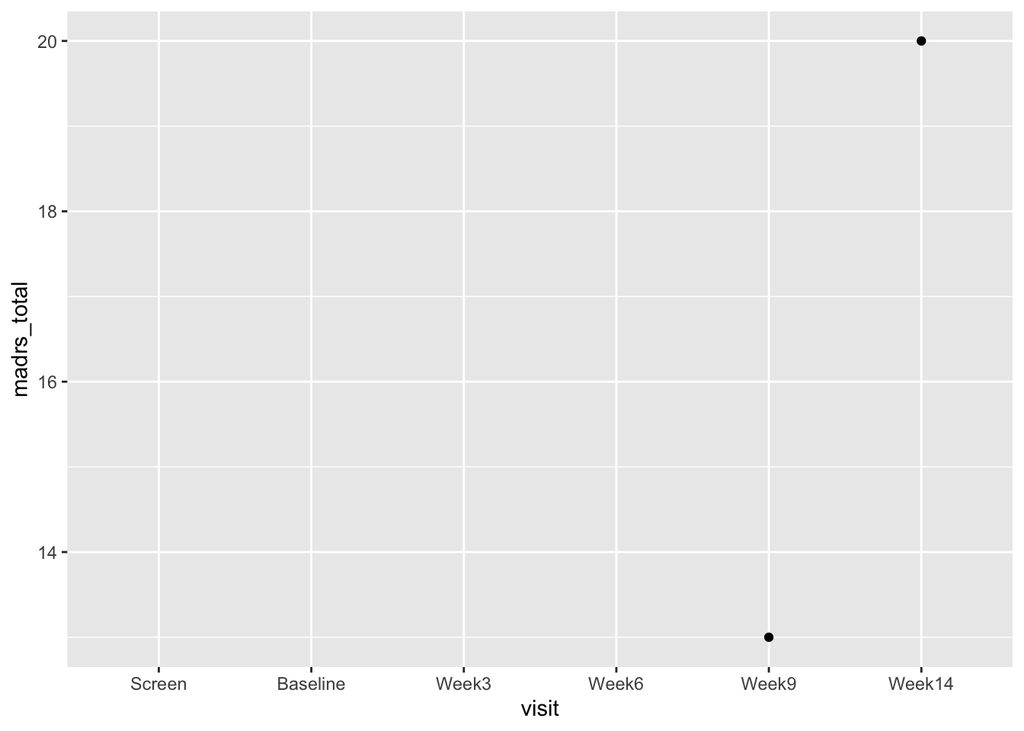

```r
#Logitudinal plot

cmpst_madrs %>%
  filter(patient_id == 4007) %>%
  ggplot(aes(x = visit, y = madrs_total )) +
  geom_point()
```

```r
##calculate the difference of negaffect


cmpst_madrs <- cmpst_madrs %>%
   mutate( visit = forcats::fct_relevel(visit, c("Screen", "Baseline", "Week3", "Week6", "Week9", "Week14", "Week24"))) %>%
  drop_na() %>%
 pivot_wider(
  names_from = "visit",
  values_from = "madrs_total",
  ) %>%
  mutate(
    change = Week14 - Baseline
  ) %>%
   janitor::clean_names() %>%
  select(-end_of_treatment)




cmpst_madrs
```

```
## # A tibble: 162 x 10
##    patient_id gender week24 week14 week9 week3 screen week6 baseline change
##         <dbl> <chr>   <dbl>  <dbl> <dbl> <dbl>  <dbl> <dbl>    <dbl>  <dbl>
##  1       4000 Female      2     NA    NA    NA     NA    NA       NA     NA
##  2       4001 Female     24     NA    NA    NA     NA    NA       NA     NA
##  3       4006 Male       NA     21    18    NA     NA    NA       NA     NA
##  4       4007 Male       NA     20    13    NA     NA    NA       NA     NA
##  5       4010 Female     28     30    NA    17     NA    NA       NA     NA
##  6       4011 Female     NA     NA    NA     8     28    14       NA     NA
##  7       4012 Female      0     10    10    11     21    17       13     -3
##  8       4013 Female     10      8    15    20     17    14        8      0
##  9       4014 Female     21     21    29    15     23    24       23     -2
## 10       4019 Female     36     35    29    39     24    37       38     -3
## # … with 152 more rows
```